# Lab 3: Analisi de Correspondencies i Normal multivariant

Álvaro Ribot

## Exercici 1: Anticonceptius a indonesia

```r
#library("FactoMineR")
library("ca")
library("MASS")
```

### a)

```r
X <- read.table("http://www-eio.upc.es/~jan/Data/MVA/cmc.dat", header = T, sep = ",")
head(X)
```

|  | Age | WifeEduc | HusbEduc | Childs | Rel | Work | Occup | Standard | Media | Method |
| --- | --- | --- | --- | --- | --- | --- | --- | --- | --- | --- |
| 1 | 24 | 2 | 3 | 3 | 1 | 1 | 2 | 3 | 0 | 1 |
| 2 | 45 | 1 | 3 | 10 | 1 | 1 | 3 | 4 | 0 | 1 |
| 3 | 43 | 2 | 3 | 7 | 1 | 1 | 3 | 4 | 0 | 1 |
| 4 | 42 | 3 | 2 | 9 | 1 | 1 | 3 | 3 | 0 | 1 |
| 5 | 36 | 3 | 3 | 8 | 1 | 1 | 3 | 2 | 0 | 1 |
| 6 | 19 | 4 | 4 | 0 | 1 | 1 | 3 | 3 | 0 | 1 |

```r
for (i in 1:ncol(X)) {
  print(range(X[,i]))
}
```

```
[1] 16 49
[1] 1 4
[1] 1 4
[1]  0 16
[1] 0 1
[1] 0 1
[1] 1 4
[1] 1 4
[1] 0 1
[1] 1 3
```

Podem observar que el rang dels valors que prenen les variables categoriques coinicideix amb el de la seva codificacio. Per tant, podem concloure que no hi ha dades mancants.

### b)

```r
X$Method <- factor(X$Method, levels = c(1, 2, 3), labels = c("none", "long-term", "mid-term"))
X$WifeEduc <- factor(X$WifeEduc, levels = c(1, 2, 3, 4), labels = c("low", "prim", "mid", "high"))
```

### c)

```r
(taula <- table(X$Method, X$WifeEduc))
```

```
            low prim mid high
  none      103  176 175  175
  long-term   9   37  80  207
  mid-term   40  121 155  195
```

### d)

```r
chisq.test(taula)
```

```
    Pearson's Chi-squared test

data:  taula
X-squared = 140.46, df = 6, p-value < 2.2e-16
```

L’estadistic de prova pren valor $140.46$ i el p-valor es mes petit que $2.2e-16$. Per tant, podem concluir que hi ha associacio entre les variables (rebutgem la hipotessi nul·la que assumeix independència)

### e)

```r
out <- ca(taula)
(r <- out$rowmass)
```

```
[1] 0.4270197 0.2260692 0.3469111
```

```r
(c <- out$colmass)
```

```
[1] 0.1031908 0.2267481 0.2783435 0.3917176
```

Podem veure els pesos de *Method* i de *WifeEduc*, respectivament. Per tant, el métode conceptiu més utilitzat es “none”.

### f)

Es mostren les matrius de perfils fila i columna, respectivament.

```r
P <- as.matrix(taula)
P <- P/sum(P) # matriu de probabilitats
(R <- diag(1/r)%*%P)
```

```
              low      prim       mid      high
  [1,] 0.16375199 0.2798092 0.2782194 0.2782194
  [2,] 0.02702703 0.1111111 0.2402402 0.6216216
  [3,] 0.07827789 0.2367906 0.3033268 0.3816047
```

```r
(C <- diag(1/c)%*%t(P))
```

```
            none  long-term  mid-term
  [1,] 0.6776316 0.05921053 0.2631579
  [2,] 0.5269461 0.11077844 0.3622754
  [3,] 0.4268293 0.19512195 0.3780488
  [4,] 0.3032929 0.35875217 0.3379549
```

### g) **Mirar que es perfil marginal**

```r
(marg <- apply(P, 2, sum))
```

```
      low      prim       mid      high
0.1031908 0.2267481 0.2783435 0.3917176
```

```r
dist(rbind(marg, R[3,]))
```

```
       marg
 0.03805178
```

### h)

```r
resultats <- ca(taula)
summary(resultats)
```

```
Principal inertias (eigenvalues):

 dim    value      %   cum%   scree plot
 1      0.090755  95.2  95.2  ************************
 2      0.004600   4.8 100.0  *
        -------- -----
 Total: 0.095356 100.0


Rows:
    name   mass  qlt  inr    k=1 cor ctr    k=2 cor ctr
1 | none |  427 1000  362 | -280 973 370 |   47  27 203 |
2 | lngt |  226 1000  605 |  502 988 629 |   54  12 145 |
3 | mdtr |  347 1000   33 |   18  36   1 |  -93 964 652 |

Columns:
    name   mass  qlt  inr    k=1 cor ctr    k=2 cor ctr
1 |  low |  103 1000  314 | -517 919 303 |  154  81 531 |
2 | prim |  227 1000  197 | -284 976 202 |  -45  24  98 |
3 |  mid |  278 1000   21 |  -50 350   8 |  -68 650 277 |
4 | high |  392 1000  468 |  336 990 487 |   33  10  95 |
```

Existeixen dues dimensions, però observem que amb una dimensió ja obtenim el $95.2\%$. Per tant, podem representar adequadament la taula de contingencia amb una dimensio.

### i)

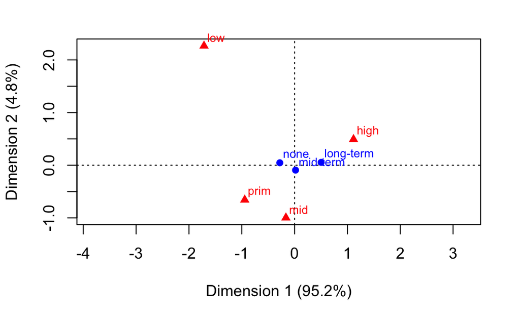

```r
plot(resultats, map = "rowprincipal")
```

### k)

```r
X$Age <- as.factor(cut(X$Age, breaks = 4))
table(X$Age)
```

```
  (16,24.2] (24.2,32.5] (32.5,40.8]   (40.8,49]
        276         504         387         306
```

### l)

```r
X$AgeRel <- with(X, interaction(Age, Rel))
table(X$AgeRel)/nrow(X)
```

```
  (16,24.2].0 (24.2,32.5].0 (32.5,40.8].0   (40.8,49].0   (16,24.2].1
  0.009504413   0.042090971   0.060420910   0.037338764   0.177868296
(24.2,32.5].1 (32.5,40.8].1   (40.8,49].1
  0.300067889   0.202308215   0.170400543
```

### m)

```r
(taula2 <- table(X$Method, X$AgeRel))
```

```
            (16,24.2].0 (24.2,32.5].0 (32.5,40.8].0 (40.8,49].0
  none                5            22            27          21
  long-term           2            18            32          24
  mid-term            7            22            30          10

            (16,24.2].1 (24.2,32.5].1 (32.5,40.8].1 (40.8,49].1
  none              121           170           109         154
  long-term          35            77            85          60
  mid-term          106           195           104          37
```

### n)

```r
summary(resultats2 <- ca(taula2))
```

```
Principal inertias (eigenvalues):

 dim    value      %   cum%   scree plot
 1      0.050065  62.9  62.9  ****************
 2      0.029557  37.1 100.0  *********
        -------- -----
 Total: 0.079622 100.0


Rows:
    name   mass  qlt  inr    k=1 cor ctr    k=2 cor ctr
1 | none |  427 1000  256 | -141 414 169 |  167 586 404 |
2 | lngt |  226 1000  335 | -203 349 186 | -277 651 588 |
3 | mdtr |  347 1000  409 |  305 993 646 |  -25   7   7 |

Columns:
       name   mass  qlt  inr    k=1 cor ctr    k=2  cor ctr
1 |  162420 |   10 1000   13 |  328 983  20 |   44   17   1 |
2 | 2423250 |   42 1000   16 |   -2   0   0 | -175 1000  44 |
3 | 3254080 |   60 1000   87 |  -57  28   4 | -334  972 228 |
4 |  408490 |   37 1000  131 | -387 538 112 | -359  462 163 |
5 |  162421 |  178 1000  112 |  141 394  70 |  175  606 183 |
6 | 2423251 |  300 1000  157 |  202 980 245 |   29   20   8 |
7 | 3254081 |  202 1000   62 |  -12   6   1 | -155  994 165 |
8 |  408491 |  170 1000  421 | -401 817 548 |  190  183 208 |
```

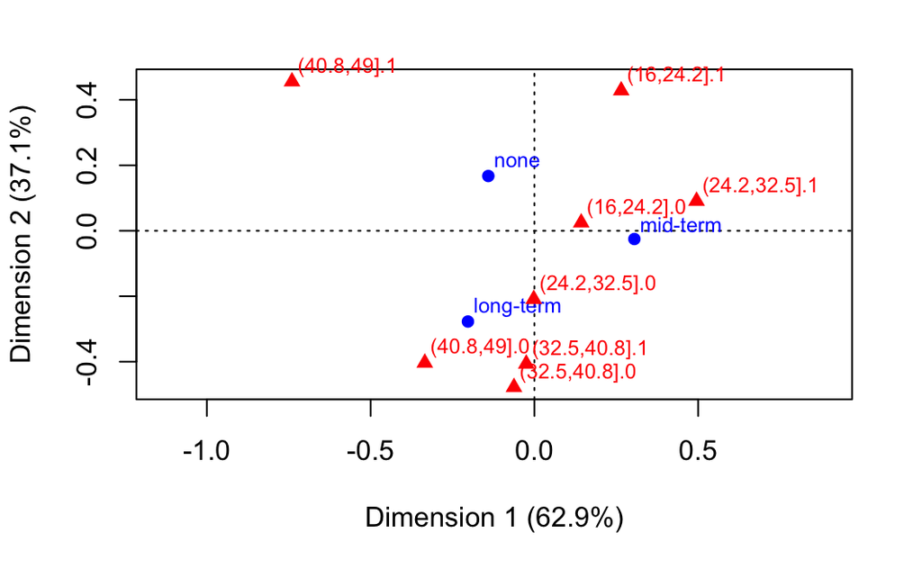

```r
plot(resultats2, map = "rowgreen")
```

En aquest cas observem que son necessaries dues dimensions per fer una bona representació de la taula de contingencia, ja que amb una dimensio nomes representariem be un $62.9\%$.

En general, les dones que practiquen la religio islamica tendeixen a utilitzar menys metodes anticonceptius que les no creients. Tambe podem notar que les dones joves tendeixen a utilitzar metodes anticonceptius de curt termini i a mesura que es fan gran utilitzen els de llarg termini.

### o)

```r
tmult <- table(X[,c("Method", "WifeEduc", "AgeRel")])
summary(acmult <- mjca(tmult, lambda = "indicator"))
```

```
Principal inertias (eigenvalues):

 dim    value      %   cum%   scree plot
 1      0.490556  12.3  12.3  ***
 2      0.456773  11.4  23.7  ***
 3      0.357164   8.9  32.6  **
 4      0.345038   8.6  41.2  **
 5      0.334913   8.4  49.6  **
 6      0.333333   8.3  57.9  **
 7      0.333333   8.3  66.3  **
 8      0.321610   8.0  74.3  **
 9      0.299496   7.5  81.8  **
 10     0.279349   7.0  88.8  **
 11     0.232542   5.8  94.6  *
 12     0.215894   5.4 100.0  *
```

[output cut: 37 more lines]

L’anàlisi té $12$ dimensions, i la inercia de la matriu d’indicadors es $4$. En dues dimensions la bondat de l’ajust és del $23.7\%$.

### p) **falta interpretar**

```r
head(X)
```

|  | Age | WifeEduc | HusbEduc | Childs | Rel | Work | Occup | Standard | Media | Method | AgeRel |
| --- | --- | --- | --- | --- | --- | --- | --- | --- | --- | --- | --- |
| 1 | (16,24.2] | prim | 3 | 3 | 1 | 1 | 2 | 3 | 0 | none | (16,24.2].1 |
| 2 | (40.8,49] | low | 3 | 10 | 1 | 1 | 3 | 4 | 0 | none | (40.8,49].1 |
| 3 | (40.8,49] | prim | 3 | 7 | 1 | 1 | 3 | 4 | 0 | none | (40.8,49].1 |
| 4 | (40.8,49] | mid | 2 | 9 | 1 | 1 | 3 | 3 | 0 | none | (40.8,49].1 |
| 5 | (32.5,40.8] | mid | 3 | 8 | 1 | 1 | 3 | 2 | 0 | none | (32.5,40.8].1 |
| 6 | (16,24.2] | high | 4 | 0 | 1 | 1 | 3 | 3 | 0 | none | (16,24.2].1 |

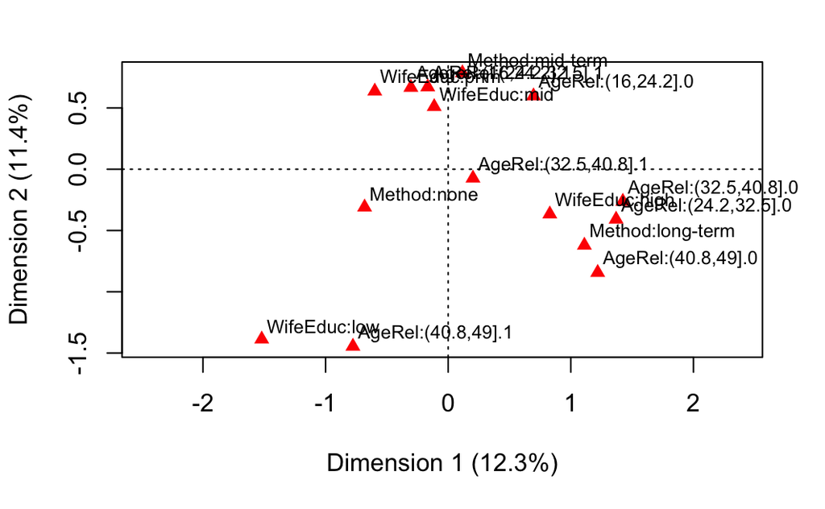

```r
plot(acmult)
```

### q)

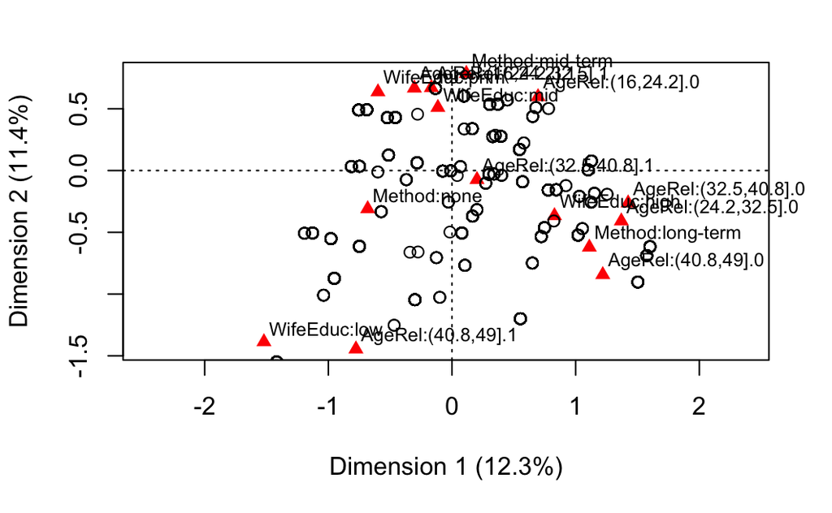

```r
plot(acmult)
points(acmult$rowpcoord)
```

### r)

```r
summary(B <- mjca(tmult, lambda = "Burt"))
```

```
Principal inertias (eigenvalues):

 dim    value      %   cum%   scree plot
 1      0.240645  17.2  17.2  ****
 2      0.208641  14.9  32.0  ****
 3      0.127566   9.1  41.1  **
 4      0.119051   8.5  49.6  **
 5      0.112167   8.0  57.6  **
 6      0.111111   7.9  65.6  **
 7      0.111111   7.9  73.5  **
 8      0.103433   7.4  80.9  **
 9      0.089698   6.4  87.3  **
 10     0.078036   5.6  92.8  *
 11     0.054076   3.9  96.7  *
 12     0.046610   3.3 100.0  *
```

[output cut: 37 more lines]

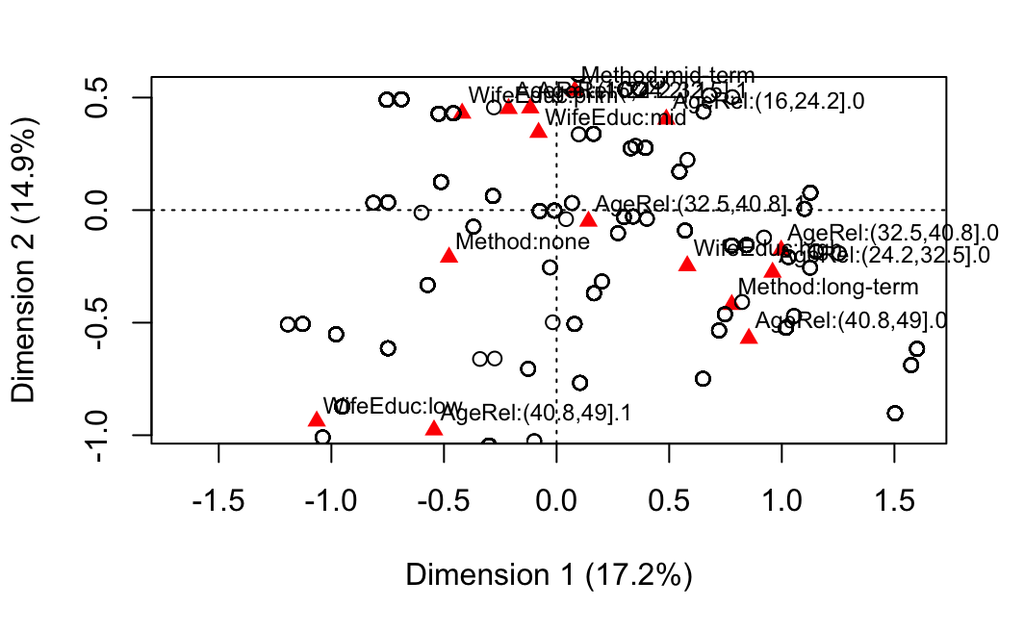

```r
plot(B)
points(B$rowpcoord[,1], B$rowpcoord[,2])
```

S’assembla molt a l’analisi utilitzant la matriu d’indicadors. El plot sembla el mateix pero escalat. Tot i amb això, amb dues dimension s’obté una bondat d’ajust del $32.0\%$, mentre que amb la matriu d’indicadors aconseguiem un $23.7\%$. Podem veure també aquesta diferència comparant els screeplots dels summaries dels dos anàlisis.

# Exercici 2: Distribució de característiques esquelètiques

```r
library("ellipse")
library("ICSNP")
```

### a)

```r
dd <- read.table("http://www-eio.upc.es/~jan/Data/MVA/body.dat")[,c(1:9, 25)]
names(dd) <- c("Biacromial", "Biilical", "Bitrochanteric", "Chest_depth", "Chest_diam", "Elbow", "Wrist", "Knee", "Ankle", "Gender")
dd$Gender <- factor(dd$Gender, levels = c(0, 1), labels = c("female", "male"))
```

### b)

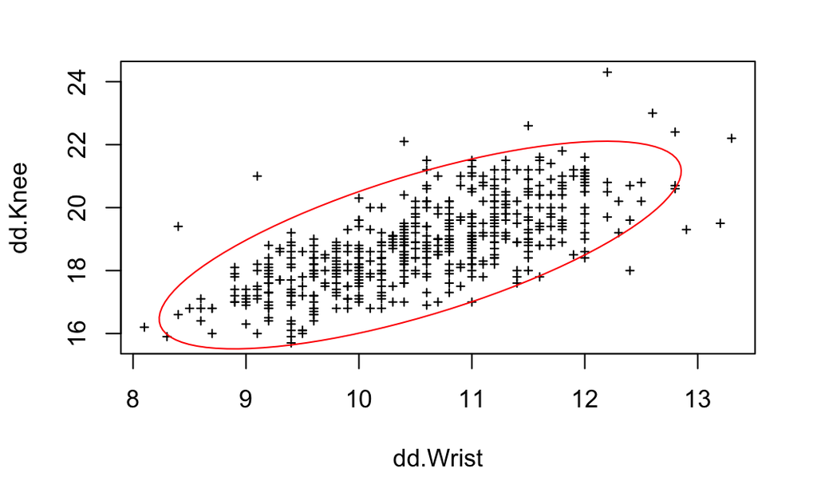

```r
WK <- data.frame(dd$Wrist, dd$Knee)
plot(WK, pch = 3, cex = 0.5)
Z <- ellipse(cov(WK), level = 0.95, centre = colMeans(WK))
points(Z, type = "l", col = "red")
```

### c) Mirant la grafica podem observar que hi ha 19 punts fora de l’elipse, y el nombre que esperariem es 25.

```r
print(exp <- nrow(dd)*5/100)
```

```
[1] 25.35
```

### e)

```r
df <- dd[dd$Gender == "female",1:9]
```

### f)

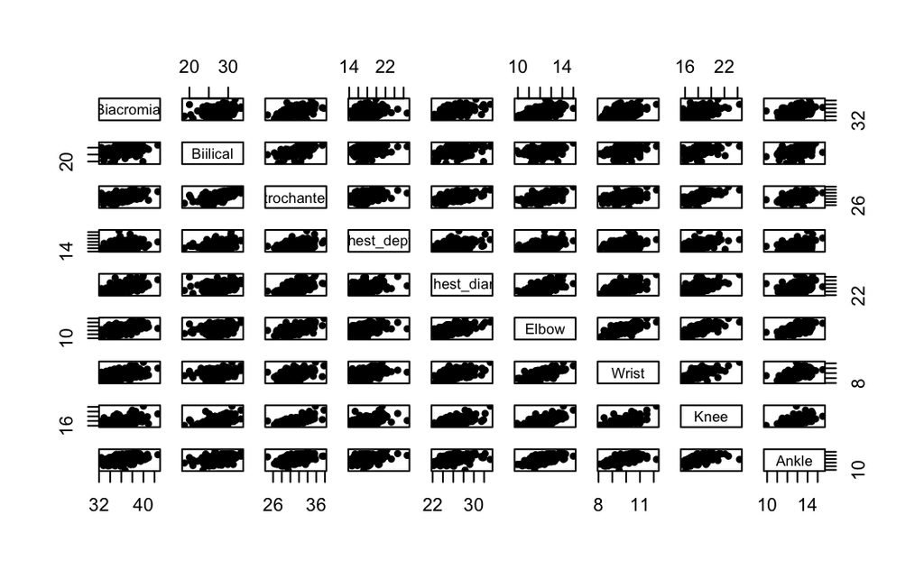

```r
pairs(df, pch = 20)
```

### g)

```r
chisq_plot <- function(X){
  M <- as.matrix(scale(X, center = T, scale = F))
  S <- solve(cov(X))
  v <- c()
  for (i in 1:nrow(M)) {
    aux <- t(M[i,])%*%S%*%M[i,]
    v <- c(v, aux)
  }
  sort(v)
}
(chp <- chisq_plot(df))
```

```
  [1]  1.614854  1.876730  2.135547  2.293399  2.361022  2.461525
  [7]  2.519774  2.546432  2.661758  2.782444  3.011668  3.096715
 [13]  3.107248  3.116671  3.121416  3.244018  3.283014  3.290570
 [19]  3.309792  3.445509  3.485289  3.490559  3.492904  3.500346
 [25]  3.553546  3.589107  3.840341  3.879719  3.971242  3.985971
 [31]  4.005135  4.017084  4.051308  4.076136  4.096903  4.112500
 [37]  4.129188  4.137548  4.140787  4.175190  4.197765  4.207455
 [43]  4.234116  4.274493  4.330855  4.333695  4.346814  4.398121
 [49]  4.439471  4.455623  4.456969  4.467459  4.471037  4.486168
 [55]  4.493606  4.494330  4.513944  4.523815  4.592725  4.642134
 [61]  4.650526  4.666414  4.670324  4.744588  4.916874  4.928640
 [67]  5.010485  5.094324  5.122366  5.130664  5.136954  5.237419
 [73]  5.260757  5.261181  5.301205  5.331515  5.369237  5.383553
 [79]  5.389557  5.419807  5.481445  5.506699  5.507348  5.522246
 [85]  5.684349  5.719844  5.725653  5.803130  5.827665  5.835961
```

[output cut: 29 more lines]

### h) Cal aplicar 9 graus de llibertat, que es el nombre de variables que tenim.

```r
rang <- c()
n <- length(chp)
for (i in 1:n){
  rang <- c(rang, (i-1/2)/n)
}
(q <- qchisq(rang, 9))
```

```
  [1]  1.356680  1.801585  2.065751  2.265573  2.430587  2.573321
  [7]  2.700389  2.815752  2.921986  3.020876  3.113711  3.201456
 [13]  3.284855  3.364494  3.440846  3.514296  3.585162  3.653714
 [19]  3.720178  3.784749  3.847596  3.908865  3.968684  4.027167
 [25]  4.084413  4.140514  4.195547  4.249587  4.302697  4.354938
 [31]  4.406363  4.457020  4.506956  4.556212  4.604825  4.652832
 [37]  4.700264  4.747151  4.793523  4.839405  4.884822  4.929796
 [43]  4.974350  5.018503  5.062275  5.105683  5.148744  5.191474
 [49]  5.233888  5.276002  5.317827  5.359377  5.400665  5.441702
 [55]  5.482499  5.523067  5.563416  5.603556  5.643497  5.683246
 [61]  5.722814  5.762207  5.801434  5.840503  5.879421  5.918195
 [67]  5.956833  5.995340  6.033723  6.071989  6.110143  6.148191
 [73]  6.186139  6.223993  6.261757  6.299438  6.337040  6.374568
 [79]  6.412027  6.449422  6.486757  6.524038  6.561267  6.598451
 [85]  6.635592  6.672695  6.709765  6.746805  6.783819  6.820812
```

[output cut: 29 more lines]

### i) Sembla que al principi segueixen molt la tendencia de ser normal bivariant pero al final podem observar outliers que tenen una distancia molt mes gran a l’esperada.

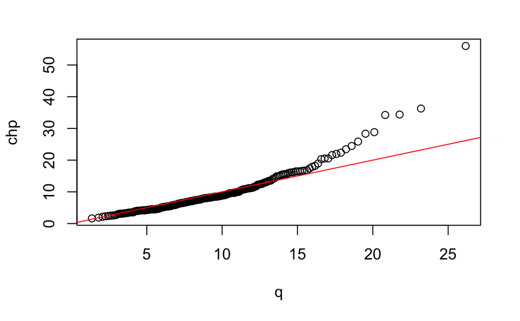

```r
plot(q, chp)
abline(0,1, col = "red")
```

### j) Podem observar que es creible la normalitat marginal de les variables.

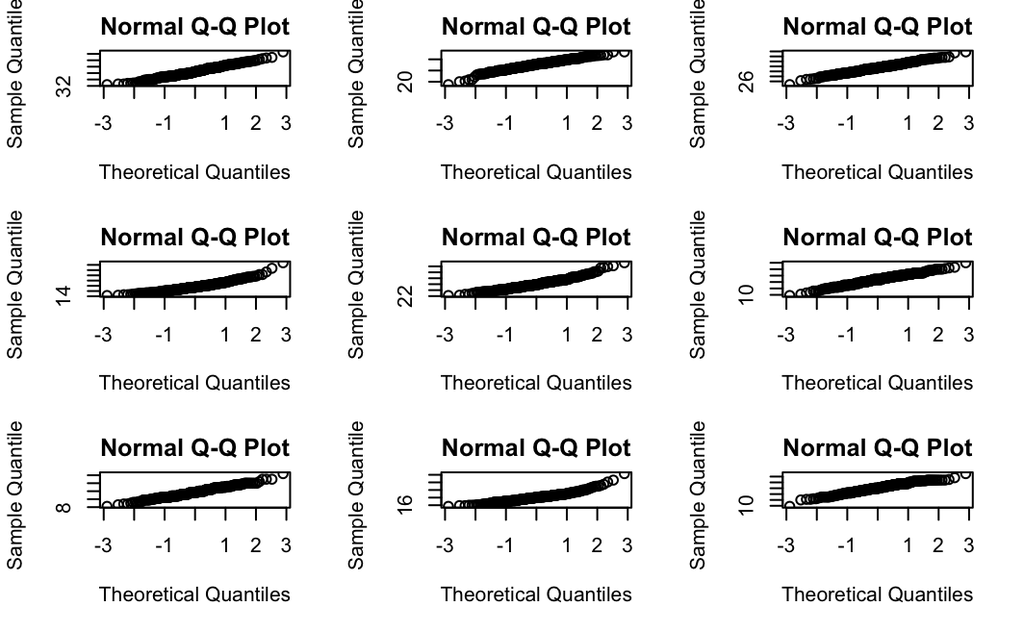

```r
par(mfrow = c(3, 3))
for (i in 1:9) {
  qqnorm(df[,i])
}
```

### k) Obtenim resultats similars als anteriors

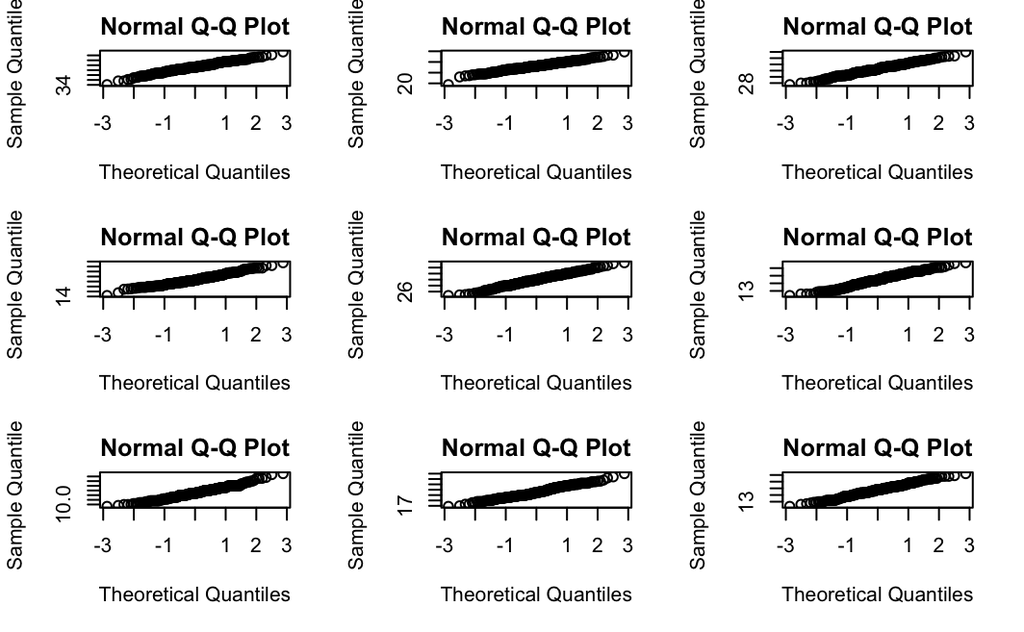

```r
dh <- dd[dd$Gender == "male",1:9]
par(mfrow=c(3,3))
for (i in 1:9){
  qqnorm(dh[,i])
}
```

### l) Existeixen diferencies significatives

```r
HotellingsT2(df, dh, test = "f")
```

```
    Hotelling's two sample T2-test

data:  df and dh
T.2 = 175.74, df1 = 9, df2 = 497, p-value < 2.2e-16
alternative hypothesis: true location difference is not equal to c(0,0,0,0,0,0,0,0,0)
```

Obtenim un estadístic $T^2 = 175.74$, i un p-valor més petit que $2.2\mathrm{e}-16$.

### m) No es rellevant com podem veure a continuacio

```r
HotellingsT2(df, dh, test = "chi")
```

```
    Hotelling's two sample T2-test

data:  df and dh
T.2 = 1607.1, df = 9, p-value < 2.2e-16
alternative hypothesis: true location difference is not equal to c(0,0,0,0,0,0,0,0,0)
```

### n)

```r
t.test(df$Biacromial, dh$Biacromial, conf.level = 0.999)
```

```
    Welch Two Sample t-test

data:  df$Biacromial and dh$Biacromial
t = -27.442, df = 483.86, p-value < 2.2e-16
alternative hypothesis: true difference in means is not equal to 0
99.9 percent confidence interval:
 -5.309859 -4.166579
sample estimates:
mean of x mean of y
 36.50308  41.24130
```

```r
t.test(df$Biilical, dh$Biilical, conf.level = 0.999)
```

```
    Welch Two Sample t-test

data:  df$Biilical and dh$Biilical
t = -2.6237, df = 503.28, p-value = 0.008962
alternative hypothesis: true difference in means is not equal to 0
99.9 percent confidence interval:
 -1.1533009  0.1333819
sample estimates:
mean of x mean of y
 27.58154  28.09150
```

```r
t.test(df$Bitrochanteric, dh$Bitrochanteric, conf.level = 0.999)
```

```
    Welch Two Sample t-test

data:  df$Bitrochanteric and dh$Bitrochanteric
t = -6.1259, df = 504.08, p-value = 1.817e-09
alternative hypothesis: true difference in means is not equal to 0
99.9 percent confidence interval:
 -1.6407143 -0.4896501
sample estimates:
mean of x mean of y
 31.46154  32.52672
```

```r
t.test(df$Chest_depth, dh$Chest_depth, conf.level = 0.999)
```

```
    Welch Two Sample t-test

data:  df$Chest_depth and dh$Chest_depth
t = -17.361, df = 484.34, p-value < 2.2e-16
alternative hypothesis: true difference in means is not equal to 0
99.9 percent confidence interval:
 -3.669583 -2.494142
sample estimates:
mean of x mean of y
 17.72462  20.80648
```

```r
t.test(df$Chest_diam, dh$Chest_diam, conf.level = 0.999)
```

```
    Welch Two Sample t-test

data:  df$Chest_diam and dh$Chest_diam
t = -22.13, df = 488.16, p-value < 2.2e-16
alternative hypothesis: true difference in means is not equal to 0
99.9 percent confidence interval:
 -4.427866 -3.275494
sample estimates:
mean of x mean of y
 26.09731  29.94899
```

```r
t.test(df$Elbow, dh$Elbow, conf.level = 0.999)
```

```
    Welch Two Sample t-test

data:  df$Elbow and dh$Elbow
t = -27.342, df = 499.49, p-value < 2.2e-16
alternative hypothesis: true difference in means is not equal to 0
99.9 percent confidence interval:
 -2.343203 -1.837121
sample estimates:
mean of x mean of y
 12.36692  14.45709
```

```r
t.test(df$Wrist, dh$Wrist, conf.level = 0.999)
```

```
    Welch Two Sample t-test

data:  df$Wrist and dh$Wrist
t = -23.807, df = 504.93, p-value < 2.2e-16
alternative hypothesis: true difference in means is not equal to 0
99.9 percent confidence interval:
 -1.562659 -1.181187
sample estimates:
mean of x mean of y
 9.874231 11.246154
```

```r
t.test(df$Knee, dh$Knee, conf.level = 0.999)
```

```
    Welch Two Sample t-test

data:  df$Knee and dh$Knee
t = -14.605, df = 503.71, p-value < 2.2e-16
alternative hypothesis: true difference in means is not equal to 0
99.9 percent confidence interval:
 -1.797047 -1.132993
sample estimates:
mean of x mean of y
 18.09692  19.56194
```

```r
t.test(df$Ankle, dh$Ankle, conf.level = 0.999)
```

```
    Welch Two Sample t-test

data:  df$Ankle and dh$Ankle
t = -21.313, df = 495.64, p-value < 2.2e-16
alternative hypothesis: true difference in means is not equal to 0
99.9 percent confidence interval:
 -1.984360 -1.450822
sample estimates:
mean of x mean of y
 13.02654  14.74413
```

Si prenem $\alpha = 0.001$ trobem diferencies significatives en totes les variables execpte en el diàmetre biilical

### o)

```r
par(mfrow=c(3,3))
boxplot(dd$Biacromial~dd$Gender)
boxplot(dd$Biilical~dd$Gender)
```

```r
boxplot(dd$Bitrochanteric~dd$Gender)
boxplot(dd$Chest_depth~dd$Gender)
```

```r
boxplot(dd$Chest_diam~dd$Gender)
boxplot(dd$Elbow~dd$Gender)
```

```r
boxplot(dd$Wrist~dd$Gender)
boxplot(dd$Knee~dd$Gender)
```

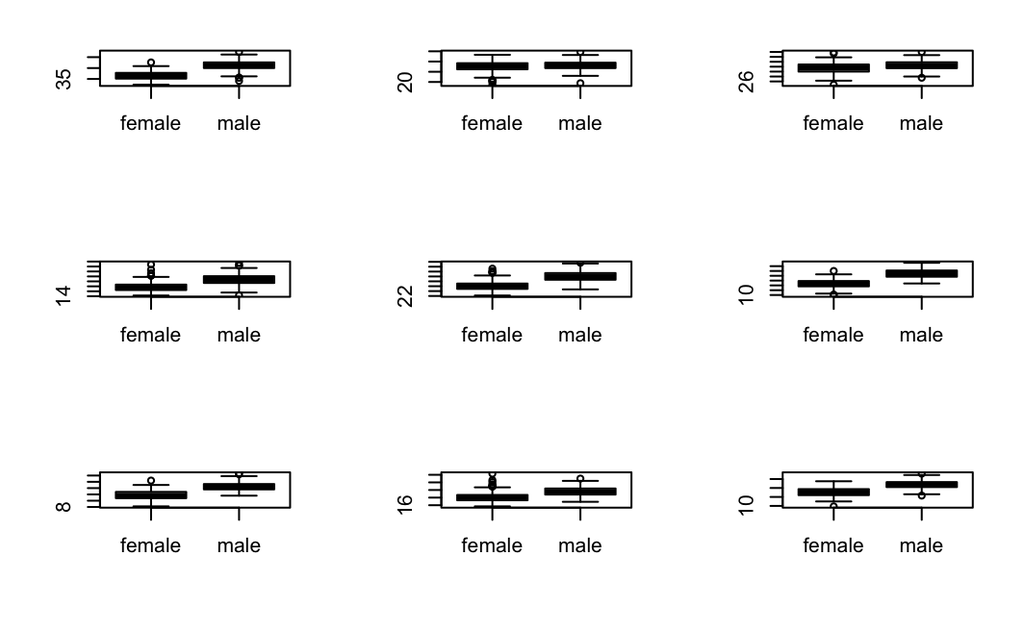

```r
boxplot(dd$Ankle~dd$Gender)
```

Observem que en general, els homes tenen mides mes grans en les diferents parts del cos (excepte pel diàmtre biilical). Una caracterísitca potser també interessant és que s’observen més outliers en els boxplots de les dones que no pas en els dels homes.